# Rent

Week 1

## Background

Here is a data table showing the available approved housing apartment options at BYU-Idaho for single students. There are 122 entries comprising 57 female and 65 male apartment options.

```r
# Code to get you started.
# View(...) works great in the Console, but datatable(...) must be
# used instead within an R-chunk.
datatable(Rent, options=list(lengthMenu = c(3,10,30)),
          extensions="Responsive",
          caption = 'Table 1: Base dataset')
```

|  | Apartment | Gender | Address | Phone | Price | PrivateRoomPrice | Capacity | ParkingStalls | Deposit | UtilityDeposit | FloorPlans | Website | Latitude | Longitude | MilesToCampus | WalkingMinutes | Description |
| --- | --- | --- | --- | --- | --- | --- | --- | --- | --- | --- | --- | --- | --- | --- | --- | --- | --- |
| 1 | ABBY LANE MANOR | F | 437 S 4TH W | (208) 359-3687 | 1035 | 1060 | 42 | 38 | 100 | 0 | 3 | www.abbylaneapartments.com | 43.8169418 | -111.7952062 | 0.746 | 16 | We are a small women's complex offering private rooms and quaint living. Many students enjoy our advantages enough that they stay with us until graduation. We are sure you would like staying with us! … |
| 2 | ABODE DUPLEX | M | 224 E 2ND S | (912) 399-1107 | 980 | 980 | 6 | 3 | 100 | 0 | 1 | sites.google.com/site/robertspencerbrown/abodehouse | 43.8218153 | -111.7771495 | 0.186 | 4 | This cozy little apartment is located only one block from campus. There are a lot of freebies for the price. All utilities are included, there is a free-to-use, in-apartment washer and dryer, free WiF… |
| 3 | ABRI APARTMENTS - MEN | M | 220 E 1ST S | 2084177223 | 1420 | 1445 | 138 | 216 | 150 | 0 | 3 | www.liveabri.com | 43.8239342 | -111.7773062 | 0.311 | 8 | 24 hour special $100 off! Look no further than the Abri, Rexburg's newest student housing community. Currently leasing women's spots for fall '17, &amp; men's for winter '18. From upscale, modern fini… |
| 4 | ABRI APARTMENTS - WOMEN | F | 220 E 1ST S | (208) 417-7223 | 1445 | 1495 | 150 | 216 | 150 | 0 | 3 | www.liveabri.com | 43.8239342 | -111.7773062 | 0.311 | 8 | $100 OFF SPECIAL! Look no further than the Abri, Rexburg's newest student housing community. Currently leasing women's spots for fall '17, &amp; men's for winter '18. From upscale, modern finishes, to… |
| 5 | ALEXANDER APARTMENT | F | 276 W 3RD S | 208-995-8543 | 972 | 1115 | 22 | 18 | 100 | 0 | 10 | www.alexanderapartments.wordpress.com | 43.8197811 | -111.7918951 | 0.435 | 8 | We are also signing for Fall and Winter 2017. Get $25 off per semester for signing 2 consecutive semesters. No application fee or parking fee and get $40 in quarters for laundry each semester. |
| 6 | ALLEN RIDGE APARTMENTS | M | 57 S CENTER ST | (801) 864-1708 | 890 | 890 | 17 | 9 | 100 | 0 | 1 | allenridge.blogspot.com | 43.824663 | -111.7835934 | 0.311 | 6 | The best kept housing secret at BYU-Idaho. Small complex (only 17 tenants), but large living areas and rooms. Private, but in the best location in town - central to campus, shopping, and great activit… |
| 7 | ALLEN'S SUNRISE VILLAGE - MEN | M | 48 W 2ND S | 356-3995 | 1000 | 1075 | 138 | 133 | 100 | 0 | 3 | www.sunrisevillageapts.com | 43.821866 | -111.7852097 | 0.062 | 1 | Allen's Sunrise Village offers housing for both men and women! We are well-known for our friendliness,low prices,great location,fantastically reliable OPTIX internet,friendly residents and amazing man… |
| 8 | ALLEN'S SUNRISE VILLAGE - WOMEN | F | 48 W 2ND S | 208-356-3995 | 1000 | 1075 | 144 | 133 | 100 | 0 | 3 | www.sunrisevillageapts.com | 43.82186 | -111.785197 | 0.062 | 1 | We offer housing for both men and women! We are well-known for our friendliness, new modern remodel, low prices, great location, our fantastically reliable OPTIX internet and amazing managers. You'll … |
| 9 | ALPINE CHALET | M | 460 S 2ND W | (208) 356-9282 | 999 | 999 | 252 | 111 | 75 | 0 | 1 | www.rexburghousing.com | 43.8165761 | -111.7895659 | 0.435 | 10 | Alpine Chalet is a great place to live! It is close to campus and surrounded by many BYUI housing complexes. It has an amazing pool, hot tub, and weight room. Not to mention, we added 2nd fridges and … |
| 10 | ALTA VIEW APARTMENTS | M | 346 W 2ND S | 208-360-0097 | 895 | 895 | 26 | 30 | 80 | 0 | 19 | www.altaviewapts.com | 43.8218751 | -111.7938578 | 0.373 | 7 | Make Alta View your home next semester. Alta View Apartments is BYUI mens approved housing. Newly remodeled, comfortable, affordable housing. Free satellite television, Optix high-speed internet, grea… |

[output cut: 97 more lines]

Does location (distance from campus) effect Rent price per semester?

## Graphic

The plot below shows the distribution of distance to campus and cost per semester.

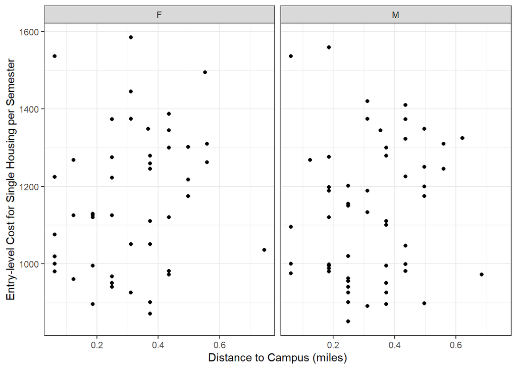

```r
# Use this R-chunk to...
# ...Create an interesting graphic using the Rent data set.

ggplot(data = Rent, aes(x = MilesToCampus, y = Price)) +
  geom_point() +
  facet_wrap(~Gender) +
  theme_bw() +
  labs(x = "Distance to Campus (miles)", y = "Entry-level Cost for Single Housing per Semester")
```

The plot doesn’t show a comparison of distance to cost. I find that interesting because Lord Harold Samuel said “Location, Location, Location.” This means that location is the most important. It would make since to have the closer to campus you are the more expensive but the data doesn’t prove that point.

```r
# Use this R-chunk to ...
# ...Wrangle, manipulate, and clean the data set.
dat1 <- Rent %>%
  group_by(MilesToCampus, Gender) %>%
  summarise(meanprice = as.numeric(round(mean(Price), digits = 0)),
            medianprice = as.numeric(round(median(Price), digits = 0)),
            maxprice = as.numeric(round(max(Price), digits = 0)),
            minprice = as.numeric(round(min(Price), digits = 0)),
            .groups = 'drop')
```

```r
# Use this R-chunk to...
# ...compute and display a meaningful table of numerical summaries supporting your above graphic.

datatable(dat1, options=list(lengthMenu = c(3,10,30)),
          caption = "Table 2: Distance, Gender and Price Comparisons")
```

|  | MilesToCampus | Gender | meanprice | medianprice | maxprice | minprice |
| --- | --- | --- | --- | --- | --- | --- |
| 1 | 0.062 | F | 1139 | 1047 | 1537 | 980 |
| 2 | 0.062 | M | 1152 | 1048 | 1537 | 975 |
| 3 | 0.124 | F | 1120 | 1125 | 1268 | 960 |
| 4 | 0.124 | M | 1268 | 1268 | 1268 | 1268 |
| 5 | 0.186 | F | 1043 | 1058 | 1129 | 895 |
| 6 | 0.186 | M | 1150 | 1154 | 1560 | 980 |
| 7 | 0.249 | F | 1122 | 1125 | 1374 | 940 |
| 8 | 0.249 | M | 1019 | 962 | 1202 | 850 |
| 9 | 0.311 | F | 1276 | 1375 | 1585 | 925 |
| 10 | 0.311 | M | 1201 | 1189 | 1420 | 890 |

[output cut: 14 more lines]

This table shows the numerical analyses of prices grouped by distance and gender. The table allows us to view the data of mean, median, max and min price which helps with understanding introduced in the graph above.